# STA 506 Final Examination

Sabah Khan

Due: May 5, 2026

## Part A: Methodological Derivations

### **Problem A1**:

Show that the density function of the Kumaraswamy distribution is

$$f(x; a, b) = ab \, x^{a-1} (1 - x^a)^{b-1}.$$
The PDF is the derivative of the CDF:

$$f(x;a,b)= d/dx, F(x;a,b) = d/dx, [1−(1−x^a) ^b]$$
The derivative of the constant 1 is 0, so:
$$f(x;a,b)=−d/dx(1−x^a) ^b$$
Applying the chain rule:

= −b(1−x^a) ^ (b−1) (d/dx(1−x^a)) =

d/dx (1−x^a)= −ax ^(a−1)

Substituting back: f(x;a,b) = −b (1−x^a) ^ (b−1) (−ax ^ (a−1))

The two negatives cancel:

f(x;a,b) = [(ab) x^ (a−1)] [(1−x ^a) ^ (b−1)]

### **Problem A2**:

Let $\{x_1, x_2, \cdots, x_n \}$ be an i.i.d. random sample taken from a population that follows the aove 2-parameter Kumaraswamy distribution. Write out the loglikelihood function of $a$ and $b$, denoted by $\ell(a,b)$, based on the above random sample and **derive** the gradient vector $[\ell_a^\prime(a,b), \ell_b^\prime(a,b)]$, the first order partial derivative of the log-likelihood with respect to parameters $a$ and $b$.

Take the natural log of the pdf:

ℓ(a,b)=i=1∑nlog[abx^(a−1) (1−x^a) ^ (b−1)]

Expanding using log properties:

ℓ(a,b)=nloga+nlogb+(a−1)i=1∑n logx +(b−1)i=1∑n log(1−(x^a))

Partial derivative with respect to b:

=(n/b) + i=1∑n log(1−(x^a))

Partial derivative with respect to a:

=(n/a) + i=1∑n logx +(b−1) i=1∑n ∂/∂a log(1−(x^a))

Applying the chain rule to the last term:

∂/∂a log(1−(x^a)) = (-x^a(log x))/(1−(x^a))

Substituting back:

n/a + i=1∑n logx - (b−1) i=1∑n (x^a(log x))/(1−(x^a))

### **Problem A3**:

Based on the gradients functions obtained in the above problem A2, **derive** the observed Fisher Information matrix (i.e, the negative Hessian Matrix).

The Observed Fisher Information Matrix is the negative Hessian:

-[ℓaa′′ℓab′′ ℓba′′ℓbb′′]

The gradients derived in A2 were:

for b: (n/b) + i=1∑n log(1−(x^a))

for a: (n/a) + i=1∑n logx - (b−1) i=1∑n (x^a(log x))/(1−(x^a))

ℓbb′′ = ∂/∂b [(n/b) + i=1∑n log(1−(x^a))] = -n/b^2

differentiate ℓb′ with respect to a:

ℓab′′ = ∂/∂a [(n/b) + i=1∑n log(1−(x^a)) ] = i=1∑n (-x^a(log x))/(1−(x^a))

differentiate ℓa′ with respect to a:

ℓaa′′ = ∂/∂a [(n/a) + logx - (b−1) i=1∑n (x^a(log x))/(1−(x^a))]

The first two terms give −n/a^2. For the last term, the quotient rule was applied:

∂/∂a (x^a(log x)) / (1−(x^a)) = [(1−(x^a) (x^a)(logx) ^2)-[(x^a(log x))(-x^a(log x))]]/((1−(x^a) ^2)

= [(x^a)(logx) ^2) (1−(x^a) + ((x^2a)(logx) ^2)]/ ((1−(x^a) ^2)

ℓaa′′ = -n/a^2 - (b-1) i=1∑n [(x^a)(logx) ^2) / ((1−(x^a) ^2)]

So the matrix is

-[ℓaa′′ℓab′′ ℓba′′ℓbb′′]

=

[(n/a^2) + (b-1) i=1∑n [(x^a)(logx) ^2) / ((1−(x^a) ^2)] , i=1∑n (x^a)(log x)))/1−(x^a), i=1∑n (x^a)(logx) / 1−(x^a), n/b^2 ]

### **Problem A4**:

Consider power distribution $F(x) = x^a, (a >0 \quad \text{ and }\quad x \in (0,1))$, a special case of the Kumaraswamy distribution with $b = 1$, and a random sample from this distribution $\{ x_1, x_2, \cdots, x_n\}$. **Derive** the MLE and MME of $a$ respectively. [*Hint: To find the MME, you need to compute the moment of the power distribution; that is, $E[X^k] = \int_0^1 x^k F'(x) dx$. Note that both the MLE and the MME have closed-form expressions.*]

When b=1, the Kumaraswamy PDF is:

f(x;a)=ax^(a-1), x∈ (0,1), a>0

The log-likelihood from A2 with b=1 is:

ℓ(a)=nloga+(a−1) i=1∑n logx + 0

since (b−1) ∑log(1-x^a) = 0 when b=1.

Taking the derivative and setting equal to zero:

ℓ′(a)= (n/a) + i=1∑n logx = 0

solving for a:

n/a = - i=1∑n logx

MLE of a = -n/(i=1∑n logx)

E[X^k]=∫ x^k F′(x)dx (integral is from zero to one)

E[X]=∫xax^(a-1)dx (integral is from zero to one) = a∫x^(a)dx= (integral is from zero to one)

= a (x^(a+1)/a+1) from zero to one, = a/a+1

Method of Moments (MME), E[X] = mean x

a/a+1 = mean x

a = mean x(a+1) = mean x(a) + (mean x)

= a - mean x(a) = mean x

a(1-mean x) = mean x

MME for a = [(mean x)/(1-mean x)]

### **Problem A5**:

Using the same setting as in **Problem A4**, find the asymptotic (Wald) confidence interval for $a$. [*Hint: Compute the Fisher information for $a$, then take its reciprocal to obtain the variance*.]

With b=1, the log-likelihood is:

ℓ(a)=nloga+(a−1) i=1∑n logx

The second derivative is:

ℓ′′(a)= -n/(a^2)

so the Fisher information is −ℓ′′(a) = n/(a^2)

The hint says that the variance is the reciprocal of the Fisher information so the variance = (a^2)/n

and the standard deviation is a/sqrt n

The Wald Confidence interval is a ± z α/2(sd(a) where z α/2 is the upper critical value of the standard normal

### **Problem A6**:

Using the same setting as in **Problem A4**, perform a likelihood ratio test for the hypothesis $H_0 :a=1$ (i.e., the power distribution reduces to a uniform distribution). [*Hint: Evaluate the log-likelihood function at the maximum likelihood estimate $\hat{a}$ and at $a=1$, then use these values to construct the LRT test statistic.*]

From A2 with b=1:

ℓ(a)=nloga+(a−1) i=1∑n logx

Log-likelihood at the MLE a-hat:

subsituting a-hat = -n/(i=1∑n logx). Let T = i=1∑n logx

ℓ(a-hat)=nlog(-n/T)+((-n/T) - 1)T

=nlog(-n/T)-n-T

Log-likelihood under H0:a=1:

ℓ(1)=nlog(1)+(1−1)i=1∑n logx = 0

LRT Statistic By Wilks’ theorem:

Λ=2[ℓ(a^)−ℓ(1)]=2[nlog(-n/T)-n-T-0]

Λ=2[nlog(-n/(i=1∑n logx))-n- i=1∑n logx]

under H0 with p-value =P(χ12>Λ) where χ12 is chi-square with 1 degree of freedom

## Part B: Numerical Analysis

**Working Dataset**: A small reservoir supplies water to a town. During the dry season (50 days), engineers record the fraction of usable storage filled each morning. Values near 0 mean the reservoir is nearly empty; values near 1 mean it’s full. The distribution tends to be right‑skewed (mostly low levels due to drought) but with occasional replenishment.

The following 50 data points (ordered for clarity) represent the daily proportion of usable storage:

```
0.12, 0.14, 0.15, 0.16, 0.17, 0.18, 0.19, 0.20, 0.21, 0.22,
0.23, 0.24, 0.25, 0.26, 0.27, 0.28, 0.29, 0.30, 0.31, 0.32,
0.33, 0.34, 0.35, 0.36, 0.37, 0.38, 0.39, 0.40, 0.41, 0.42,
0.43, 0.44, 0.45, 0.46, 0.47, 0.48, 0.49, 0.50, 0.51, 0.52,
0.53, 0.54, 0.55, 0.56, 0.57, 0.58, 0.59, 0.60, 0.61, 0.78
```

### **Problem B1**:

Fit the Kumaraswamy distribution to the above data. Use the derivations in **Problem A2** to find the MLE of $a$ and $b$. Please copy the key formulas before coding.

```r
reservoir <- c(
  0.12, 0.14, 0.15, 0.16, 0.17, 0.18, 0.19, 0.20, 0.21, 0.22,
  0.23, 0.24, 0.25, 0.26, 0.27, 0.28, 0.29, 0.30, 0.31, 0.32,
  0.33, 0.34, 0.35, 0.36, 0.37, 0.38, 0.39, 0.40, 0.41, 0.42,
  0.43, 0.44, 0.45, 0.46, 0.47, 0.48, 0.49, 0.50, 0.51, 0.52,
  0.53, 0.54, 0.55, 0.56, 0.57, 0.58, 0.59, 0.60, 0.61, 0.78
)

n <- length(reservoir)

# Log-likelihood from A2
# l(a,b) = n*log(a) + n*log(b) + (a-1)*sum(log(x)) + (b-1)*sum(log(1 - x^a))

kuma.loglik <- function(params, data) {
  a <- params[1]
  b <- params[2]
  n <- length(data)

#return -Inf for invalid parameter values
  if (a <= 0 || b <= 0) return(-Inf)

#x^a must be positive

  inner <- 1 - data^a
  if (any(inner <= 0)) return(-Inf)

  loglik <- n * log(a) +
            n * log(b) +
            (a - 1) * sum(log(data)) +
            (b - 1) * sum(log(inner))

  return(loglik)
}

# Gradient vector from A2:

# dl/da = n/a + sum(log(x)) - (b-1)*sum(x^a*log(x)/(1-x^a))
# dl/db = n/b + sum(log(1 - x^a))

kuma.score <- function(params, data) {
  a <- params[1]
  b <- params[2]
  n <- length(data)

  xa      <- data^a                    # xi^a for all i
  log.x   <- log(data)                 # log(xi) for all i
  inner   <- 1 - xa                    # 1 - xi^a for all i

  # Partial derivative w.r.t. a
  grad_a <- n / a +
            sum(log.x) -
            (b - 1) * sum(xa * log.x / inner)

  # Partial derivative w.r.t. b
  grad_b <- n / b +
            sum(log(inner))

  return(c(grad_a, grad_b))
}

# Initial Values

# Using MME of power distribution for a from A4: a = mean x/(1-mean x)
# Using b = 1 as starting point

x_bar       <- mean(reservoir)
a_init      <- x_bar / (1 - x_bar)    # MME estimate for a
b_init      <- 1                       # start for b
init.params <- c(a = a_init, b = b_init)

cat("Initial values -> a:", round(a_init, 4), "  b:", round(b_init, 4), "\n")
```

```
Initial values -> a: 0.6077   b: 1
```

```r
# Running optim with gradient

mle.result <- optim(
  par     = init.params,
  fn      = kuma.loglik,
  gr      = kuma.score,
  data    = reservoir,
  method  = "L-BFGS-B",
  lower   = c(1e-6, 1e-6),            #a > 0, b > 0
  hessian = TRUE,
  control = list(
    fnscale = -1,
    maxit   = 1000,
    abstol  = 1e-8,
    trace   = FALSE
  )
)


Hess  <- mle.result$hessian
covar <- solve(-Hess)                  # invert negative Hessian


a_hat <- mle.result$par["a"]
b_hat <- mle.result$par["b"]
se_a  <- sqrt(covar[1, 1])            # standard error of a_hat
se_b  <- sqrt(covar[2, 2])            # standard error of b_hat

cat("\n MLE Results \n",
"a_hat:", round(a_hat, 4), "  SE:", round(se_a, 4), "\n",
"b_hat:", round(b_hat, 4), "  SE:", round(se_b, 4), "\n")
```

```
 MLE Results
 a_hat: 2.5296   SE: 0.3224
 b_hat: 7.8834   SE: 2.2446
```

### **Problem B2**:

Fit the **power distribution** to the above data using the derived of $a$ obtained in **Problem A4** to test the following hypothesis using likelihood ratio procedure ar significance level $\alpha = 0.05$:

$$H_0: b = 1 \quad \text{ versus } \quad H_a: b \ne 1.$$

State the statistical decision clearly. What is the practical implication of the testing result?

```r
# Restricted MLE under H0: b = 1 (power distribution)
# Closed-form MLE from A4: a_hat = -n / sum(log(x))
# Restricted MLE of a (closed-form from A4)

# MLE of Power distribution (Kumaraswamy with b = 1)

power.mle <- function(data) {
  n <- length(data)
  a_hat <- -n / sum(log(data))
  return(a_hat)
}

a_hat <- power.mle(reservoir)
cat("H0 (b = 1) \n", "a_hat (MLE under H0):", round(a_hat, 4), "\n")
```

```
H0 (b = 1)
 a_hat (MLE under H0): 0.9393
```

```r
# Restricted log-likelihood at (a_hat, b = 1)
# From A6: l(a, b=1) = n*log(a) + (a-1)*sum(log(x))
# the (b-1)*sum(log(1 - x^a)) term vanishes when b = 1

ll_restricted <- kuma.loglik(c(a_hat, 1), reservoir)
cat("Log-likelihood at (a_hat, b=1):", round(ll_restricted, 4), "\n")
```

```
Log-likelihood at (a_hat, b=1): 0.1
```

```r
# Unrestricted MLE of (a, b) from B1

x_bar       <- mean(reservoir)
a_init      <- x_bar / (1 - x_bar)    # MME initial value for a
b_init      <- 1                       # start for b

mle.result <- optim(
  par     = c(a = a_init, b = b_init),
  fn      = kuma.loglik,
  gr      = kuma.score,
  data    = reservoir,
  method  = "L-BFGS-B",
  lower   = c(1e-6, 1e-6),            # a > 0, b > 0
  hessian = TRUE,
  control = list(
    fnscale = -1,
    maxit   = 1000,
    abstol  = 1e-8,
    trace   = FALSE
  )
)

# Unrestricted MLEs and log-likelihood
a_hat <- mle.result$par["a"]
b_hat <- mle.result$par["b"]
ll_unrestricted <- mle.result$value   # maximized log-likelihood

cat("\n Unrestricted MLE (Kumaraswamy) \n", "a_hat:", round(a_hat, 4), "b_hat:", round(b_hat, 4), "\n",


"Log-likelihood at (a_hat, b_hat):", round(ll_unrestricted, 4), "\n")
```

```
 Unrestricted MLE (Kumaraswamy)
 a_hat: 2.5296 b_hat: 7.8834
 Log-likelihood at (a_hat, b_hat): 24.5627
```

```r
# LRT Statistic

# Lambda = 2 * [l(a_hat, b_hat) - l(a_hat, 1)] ~ chi^2(1)

alpha     <- 0.05               # significance level
df        <- 1                  # 1 degree of freedom

LRT <- 2 * (ll_unrestricted - ll_restricted)

# Critical value and p-value
crit.val  <- qchisq(1 - alpha, df = df)
p.val     <- 1 - pchisq(LRT, df = df)



cat("\n Likelihood Ratio Test: H0: b = 1 vs Ha: b does not = 1 \n",
"LRT statistic:          ", round(LRT, 4),     "\n",
"Critical value (df=1):  ", round(crit.val, 4),"\n",
"p-value:                ", round(p.val, 4),   "\n")
```

```
 Likelihood Ratio Test: H0: b = 1 vs Ha: b does not = 1
 LRT statistic:           48.9253
 Critical value (df=1):   3.8415
 p-value:                 0
```

Reject the null hypothesis (that b=1. This does not fit a power distribution).

### **Problem B3**:

Use the procedure and code from **Problem B1** to estimate the MLEs of $a$ and $b$, and then complete the following analyses:

(1). Obtain the bootstrap sampling distributions of $\hat{a}$ and $\hat{b}$ and plot each distribution using **Gaussian kernel density curves**.

(2). Construct both the $95\%$ **bootstrap confidence interval** and the **Wald confidence interval** for $b$. Do these intervals agree with the results obtained in **Problem B2**? [*Compute the standard error of $\hat{b}$ using the observed Fisher information matrix, i.e., the inverse of the negative Hessian obtained from optim()*]

(3). Based on the bootstrap sampling distributions from part (1) of this problem, assess whether the validity of the Wald confidence interval is supported.

```r
# Initial values: MME for a, neutral start for b
x_bar       <- mean(reservoir)
a_init      <- x_bar / (1 - x_bar)
b_init      <- 1

# Run optim to get MLEs
mle.result <- optim(
  par     = c(a = a_init, b = b_init),
  fn      = kuma.loglik,
  gr      = kuma.score,
  data    = reservoir,
  method  = "L-BFGS-B",
  lower   = c(1e-6, 1e-6),
  hessian = TRUE,
  control = list(fnscale = -1, maxit = 1000, abstol = 1e-8, trace = FALSE)
)

a_hat <- mle.result$par["a"]     # unrestricted MLE of a
b_hat <- mle.result$par["b"]     # unrestricted MLE of b

cat(" Original MLEs \n",
"a_hat:", round(a_hat, 4), "\n",
"b_hat:", round(b_hat, 4), "\n")
```

```
 Original MLEs
 a_hat: 2.5296
 b_hat: 7.8834
```

```r
#Wald CI for b using observed Fisher Information

# Covariance matrix from negative Hessian
Hess     <- mle.result$hessian         # Hessian from optim
covar    <- solve(-Hess)               # invert negative Hessian for covariance matrix
se_b     <- sqrt(covar[2, 2])         # SE of b_hat

# 95% Wald CI for b
z_crit      <- qnorm(0.975)            # 1.96 for 95% CI
wald_ci_b   <- c(
  lower = b_hat - z_crit * se_b,
  upper = b_hat + z_crit * se_b
)

cat("\n Wald CI for b \n",
"SE of b_hat:", round(se_b, 4), "\n",
"95% Wald CI: (", round(wald_ci_b["lower.b"], 4),
    ",", round(wald_ci_b["upper.b"], 4), ")\n")
```

```
 Wald CI for b
 SE of b_hat: 2.2446
 95% Wald CI: ( 3.484 , 12.2827 )
```

These intervals agree with B2 because B2 confirmed that b does not equal 1. The Wald CI ranges from about 3 to about 12.

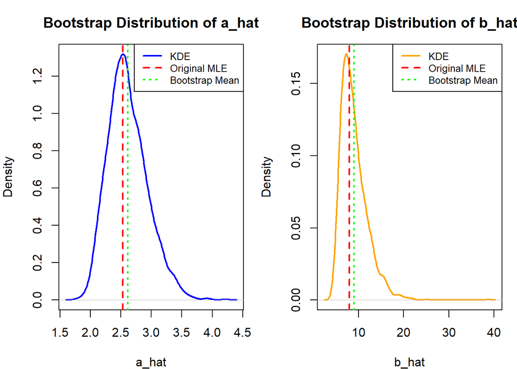

```r
set.seed(123)  #
B <- 2000      # number of bootstrap replicates


# bootstrap sample
kuma.mle.boot <- function(data, indices) {
  boot.sample <- data[indices]

  # Attempt MLE on bootstrap sample; return NA if optim did not converge
  fit <- optim(
    par     = c(a = x_bar / (1 - x_bar), b = 1),
    fn      = kuma.loglik,
    gr      = kuma.score,
    data    = boot.sample,
    method  = "L-BFGS-B",
    lower   = c(1e-6, 1e-6),
    control = list(fnscale = -1, maxit = 1000, abstol = 1e-8, trace = FALSE)
  )

  # optim() returns convergence = 0 on success, non-zero on failure
  if (fit$convergence == 0) {
    return(fit$par)          # return c(a_hat, b_hat)
  } else {
    return(c(NA, NA))        # return NA pair if optim() failed
  }
}

boot.result <- boot(
  data      = reservoir,
  statistic = kuma.mle.boot,
  R         = B
)

# Extract bootstrap distributions for a and b
boot_a <- boot.result$t[, 1]          # bootstrap a_hat values
boot_b <- boot.result$t[, 2]          # bootstrap b_hat values


# bootstrap distributions with KDE
par(mfrow = c(1, 2), mar = c(4, 4, 3, 1))

# Bootstrap distribution of a_hat
plot(density(boot_a, kernel = "gaussian"),
     main = "Bootstrap Distribution of a_hat",
     xlab = "a_hat", ylab = "Density",
     lwd = 2, col = "blue")
abline(v = a_hat, col = "red", lwd = 2, lty = 2)   # original MLE
abline(v = mean(boot_a), col = "green", lwd = 2, lty = 3) # bootstrap mean
legend("topright",
       legend = c("KDE", "Original MLE", "Bootstrap Mean"),
       col    = c("blue", "red", "green"),
       lwd    = 2, lty = c(1, 2, 3), cex = 0.8)

# Bootstrap distribution of b_hat
plot(density(boot_b, kernel = "gaussian"),
     main = "Bootstrap Distribution of b_hat",
     xlab = "b_hat", ylab = "Density",
     lwd = 2, col = "orange")
abline(v = b_hat, col = "red", lwd = 2, lty = 2)   # original MLE
abline(v = mean(boot_b), col = "green", lwd = 2, lty = 3) # bootstrap mean
legend("topright",
       legend = c("KDE", "Original MLE", "Bootstrap Mean"),
       col    = c("orange", "red", "green"),
       lwd    = 2, lty = c(1, 2, 3, 4), cex = 0.8)
```

```r
alpha <- 0.05

# Percentile bootstrap CI for b
boot_ci_b <- boot.ci(boot.result, conf = 1 - alpha,
                     type = "perc", index = 2)   # index=2 -> b

# Extract percentile CI bounds
perc_ci_b <- boot_ci_b$percent[4:5]   # [lower, upper]

cat("Bootstrap Percentile CI: (",
    round(perc_ci_b[1], 4), ",", round(perc_ci_b[2], 4), ")\n")
```

```
Bootstrap Percentile CI: ( 5.0518 , 15.9697 )
```

These intervals agree with B2 because B2 confirmed that b does not equal 1. The percentile CI ranges from about 5 to about 16.

### **Problem B4**:

In the introduction to the working model for this exam, the Kumaraswamy distribution reduces to the uniform distribution on (0,1). In this problem, we perform a **likelihood ratio test** for the following hypothesis to assess whether the data come from the uniform distribution on (0,1):

$$H_0: a = 1\quad \& \quad b = 1\quad \text{ versus } \quad H_a: a \ne
1 \quad \text{or} \quad b \ne 1 \quad \text{or}\quad (a \ne 1 \quad
\& \quad b \ne 1).$$

Provide a practical interpretation of the above test result. [*Hint: $H_a$ basically says that there is no constraints for $a$ and $b$. Please review the lecture note for module 11 on the likelihood ratio test before coding.*]

```r
mle.result <- optim(
  par     = c(a = a_init, b = b_init),
  fn      = kuma.loglik,
  gr      = kuma.score,
  data    = reservoir,
  method  = "L-BFGS-B",
  lower   = c(1e-6, 1e-6),
  hessian = TRUE,
  control = list(fnscale = -1, maxit = 1000, abstol = 1e-8, trace = FALSE)
)

a_hat           <- mle.result$par["a"]
b_hat           <- mle.result$par["b"]
ll_unrestricted <- mle.result$value      # l(a_hat, b_hat)



# Restricted log-likelihood under H0: a = 1, b = 1

ll_null <- kuma.loglik(c(1, 1), reservoir)


# LRT statistic
# LR = -2 * [l(a_hat, b_hat) - l(1, 1)] -> chi^2(df = 2)


LR <- -2 * (ll_null - ll_unrestricted)   # equivalent to 2*(ll_unrestricted - ll_null)

cat("\n Likelihood Ratio Test \n",
"H0: a = 1 AND b = 1 (Uniform distribution)\n",
"Ha: a Does not equal 1 OR b Does not equal 1 (Full Kumaraswamy)\n",
"LR statistic:", LR, "\n")
```

```
 Likelihood Ratio Test
 H0: a = 1 AND b = 1 (Uniform distribution)
 Ha: a Does not equal 1 OR b Does not equal 1 (Full Kumaraswamy)
 LR statistic: 49.12542
```

```r
# p-value (right-tailed chi-square, df = 2)

p.val <- 1 - pchisq(LR, df = 2)
cat("p-value:", p.val, "\n")
```

```
p-value: 2.150558e-11
```

Reject H0, data does not follow a uniform distribution.

A uniform distribution would imply that every storage level — from nearly empty to nearly full — is equally likely during the dry season. Rejecting means H0 means that storage levels are not uniformly distributed.